# Regression Model for [Project Name] Using R version 10

## 2. Summarize Data

To gain a better understanding of the data that we have on-hand, we will leverage a number of descriptive statistics and data visualization techniques. The plan is to use the results to consider new questions, review assumptions, and validate hypotheses that we can investigate later with specialized models.

```r
if (!muteEmail) email_notify(paste("Data Summarization and Visualization has begun!",date()))
```

```
## [1] "Java-Object{org.apache.commons.mail.SimpleEmail@6a5fc7f7}"
```

### 2.a) Descriptive statistics

#### 2.a.i) Peek at the data itself.

```r
head(xy_train)
```

```
##      CRIM   ZN INDUS CHAS   NOX    RM   AGE    DIS RAD TAX PTRATIO      B
## 1 0.00632 18.0  2.31    0 0.538 6.575  65.2 4.0900   1 296    15.3 396.90
## 2 0.02731  0.0  7.07    0 0.469 6.421  78.9 4.9671   2 242    17.8 396.90
## 3 0.02729  0.0  7.07    0 0.469 7.185  61.1 4.9671   2 242    17.8 392.83
## 4 0.03237  0.0  2.18    0 0.458 6.998  45.8 6.0622   3 222    18.7 394.63
## 7 0.08829 12.5  7.87    0 0.524 6.012  66.6 5.5605   5 311    15.2 395.60
## 9 0.21124 12.5  7.87    0 0.524 5.631 100.0 6.0821   5 311    15.2 386.63
##   LSTAT targetVar
## 1  4.98      24.0
## 2  9.14      21.6
## 3  4.03      34.7
## 4  2.94      33.4
## 7 12.43      22.9
## 9 29.93      16.5
```

#### 2.a.ii) Dimensions of the dataset.

```r
dim(xy_train)
```

```
## [1] 356  14
```

#### 2.a.iii) Types of the attributes.

```r
sapply(xy_train, class)
```

```
##      CRIM        ZN     INDUS      CHAS       NOX        RM       AGE
## "numeric" "numeric" "numeric" "integer" "numeric" "numeric" "numeric"
##       DIS       RAD       TAX   PTRATIO         B     LSTAT targetVar
## "numeric" "integer" "numeric" "numeric" "numeric" "numeric" "numeric"
```

#### 2.a.iv) Statistical summary of all attributes.

```r
summary(xy_train)
```

```
##       CRIM                ZN             INDUS             CHAS
##  Min.   : 0.00632   Min.   : 0.000   Min.   : 0.460   Min.   :0.00000
##  1st Qu.: 0.08798   1st Qu.: 0.000   1st Qu.: 5.640   1st Qu.:0.00000
##  Median : 0.27398   Median : 0.000   Median : 9.125   Median :0.00000
##  Mean   : 3.91700   Mean   :10.631   Mean   :11.124   Mean   :0.05618
##  3rd Qu.: 3.68290   3rd Qu.: 3.125   3rd Qu.:18.100   3rd Qu.:0.00000
##  Max.   :88.97620   Max.   :95.000   Max.   :27.740   Max.   :1.00000
##       NOX               RM             AGE              DIS
##  Min.   :0.3850   Min.   :3.561   Min.   :  2.90   Min.   : 1.137
##  1st Qu.:0.4480   1st Qu.:5.880   1st Qu.: 44.67   1st Qu.: 2.112
##  Median :0.5380   Median :6.214   Median : 77.75   Median : 3.272
##  Mean   :0.5533   Mean   :6.280   Mean   : 68.76   Mean   : 3.747
##  3rd Qu.:0.6240   3rd Qu.:6.629   3rd Qu.: 94.10   3rd Qu.: 5.117
##  Max.   :0.8710   Max.   :8.725   Max.   :100.00   Max.   :10.710
##       RAD              TAX           PTRATIO            B
##  Min.   : 1.000   Min.   :188.0   Min.   :12.60   Min.   :  0.32
##  1st Qu.: 4.000   1st Qu.:281.0   1st Qu.:17.40   1st Qu.:375.44
##  Median : 5.000   Median :330.0   Median :19.05   Median :391.99
##  Mean   : 9.494   Mean   :406.6   Mean   :18.48   Mean   :355.31
##  3rd Qu.:24.000   3rd Qu.:666.0   3rd Qu.:20.20   3rd Qu.:396.29
##  Max.   :24.000   Max.   :711.0   Max.   :21.20   Max.   :396.90
##      LSTAT         targetVar
##  Min.   : 1.73   Min.   : 5.00
##  1st Qu.: 7.07   1st Qu.:17.02
##  Median :11.65   Median :21.20
##  Mean   :12.62   Mean   :22.46
##  3rd Qu.:16.91   3rd Qu.:25.00
##  Max.   :37.97   Max.   :50.00
```

#### 2.a.v) Count missing values.

```r
sapply(xy_train, function(x) sum(is.na(x)))
```

```
##      CRIM        ZN     INDUS      CHAS       NOX        RM       AGE
##         0         0         0         0         0         0         0
##       DIS       RAD       TAX   PTRATIO         B     LSTAT targetVar
##         0         0         0         0         0         0         0
```

### 2.b) Data visualizations

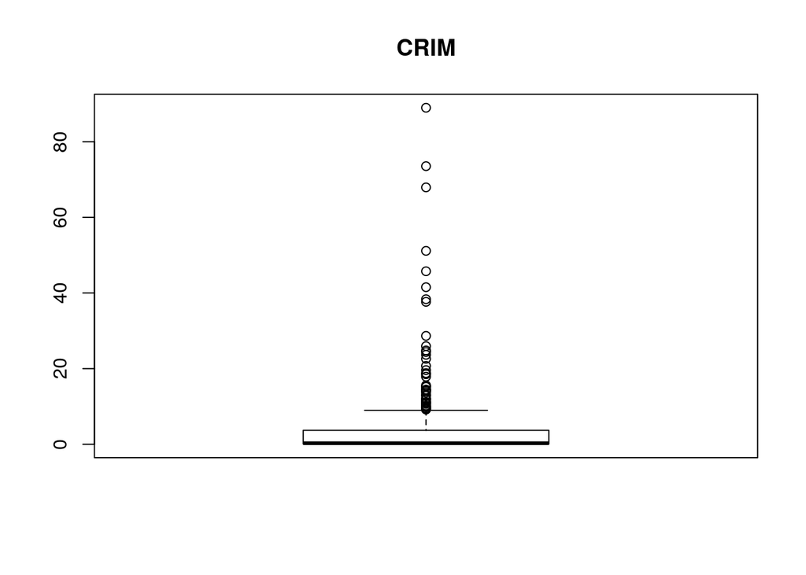

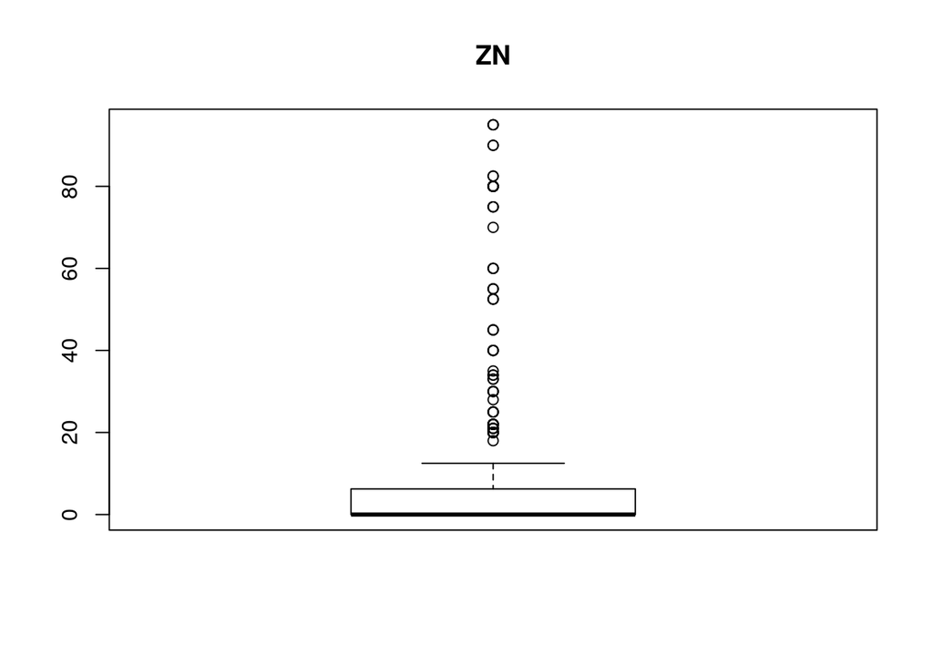

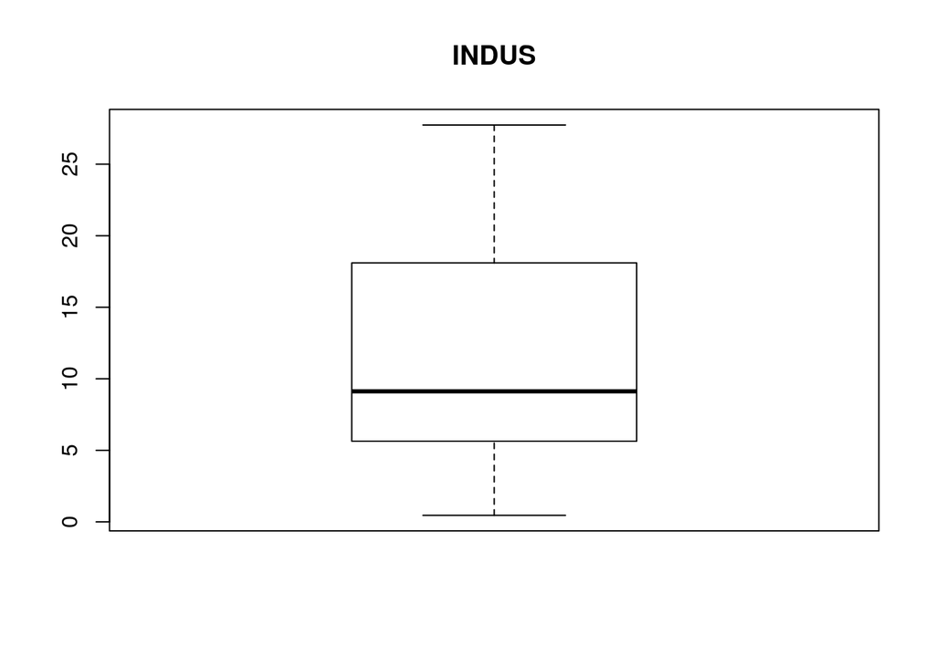

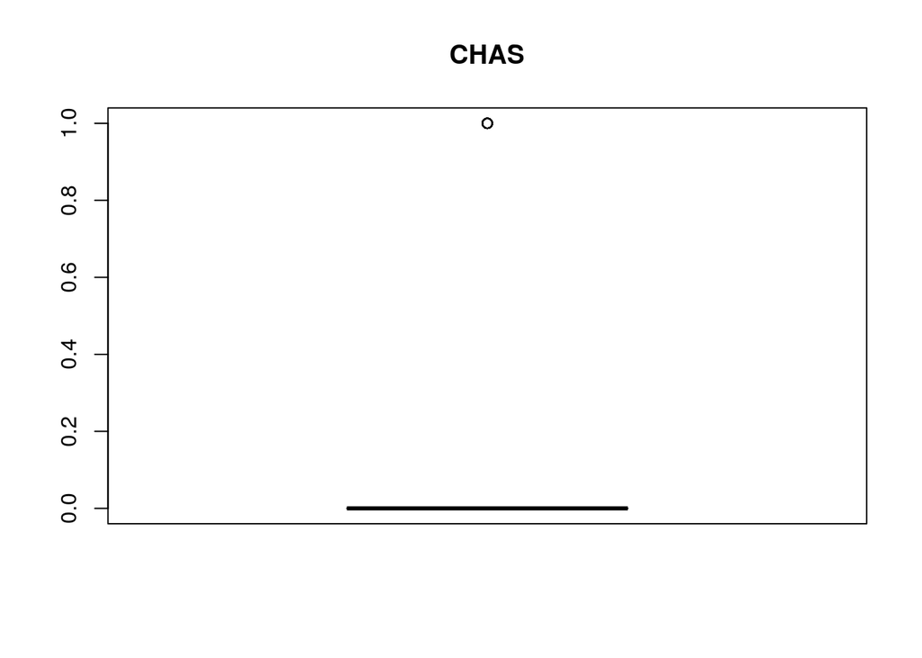

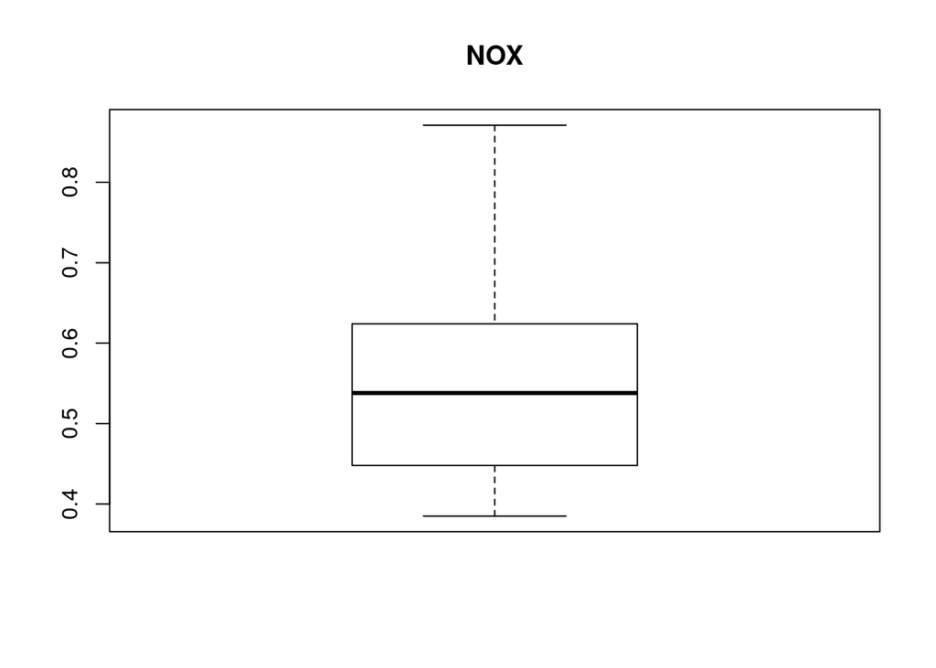

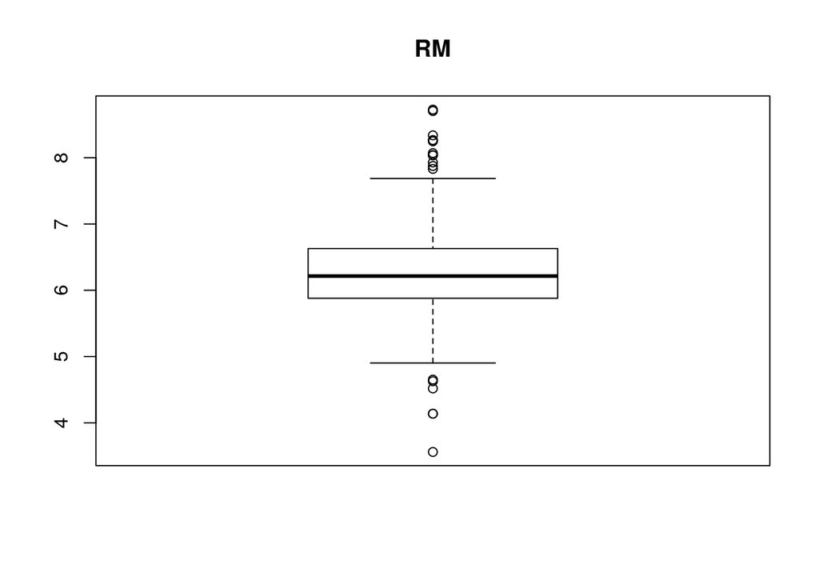

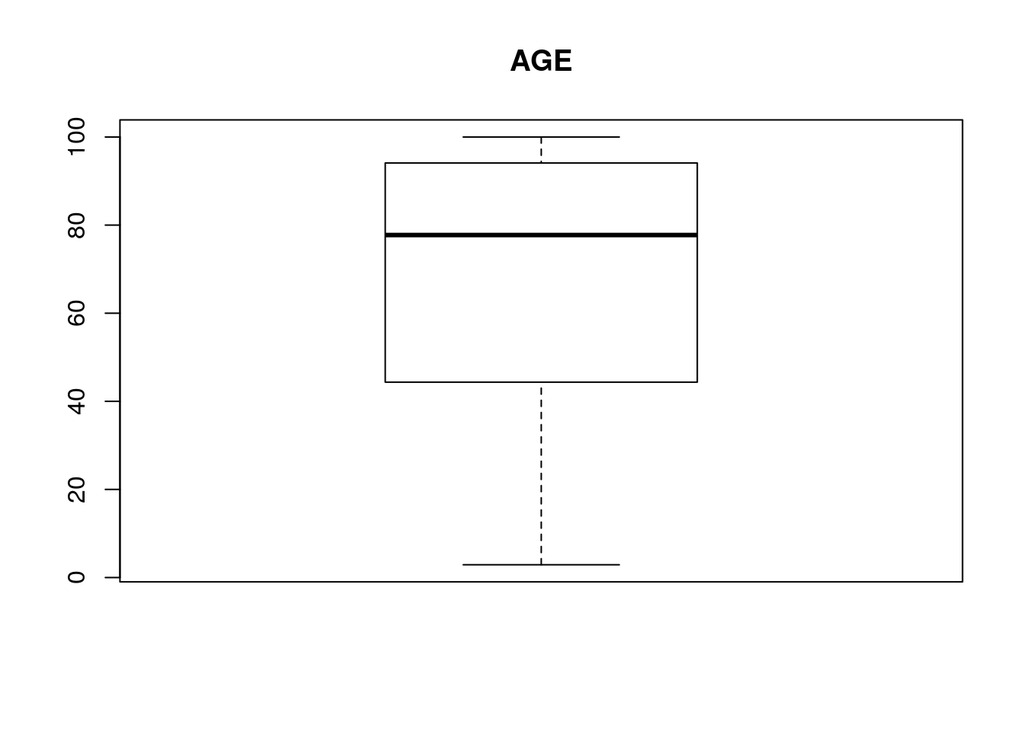

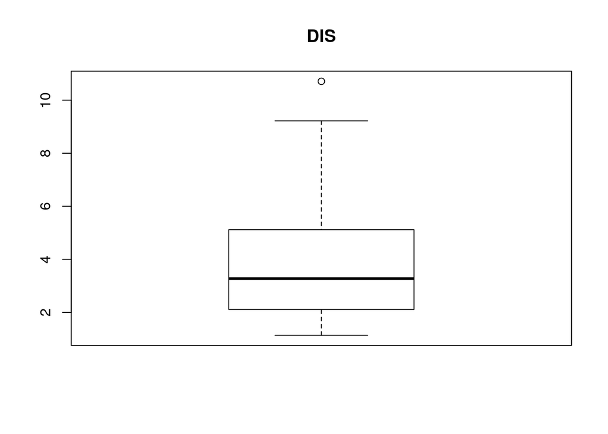

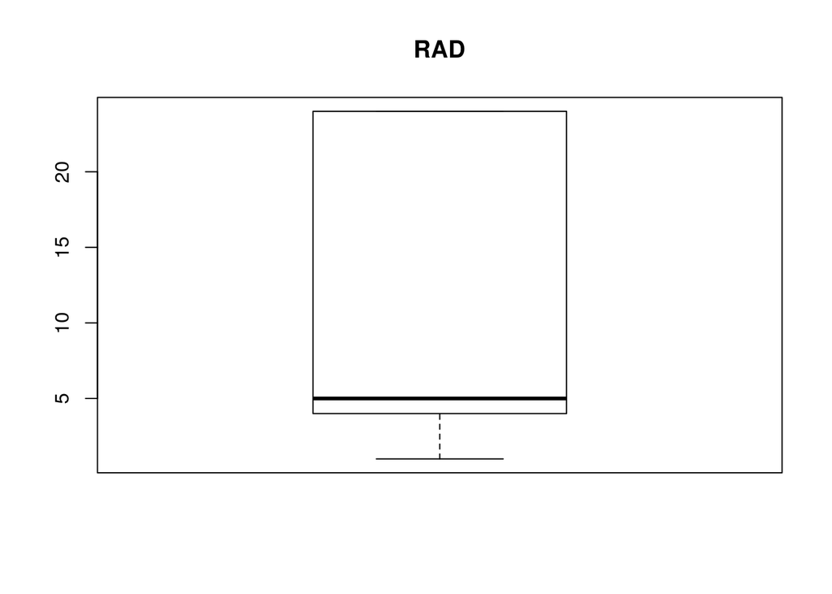

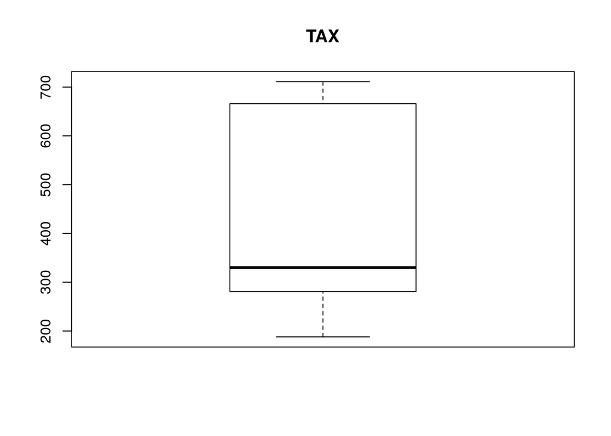

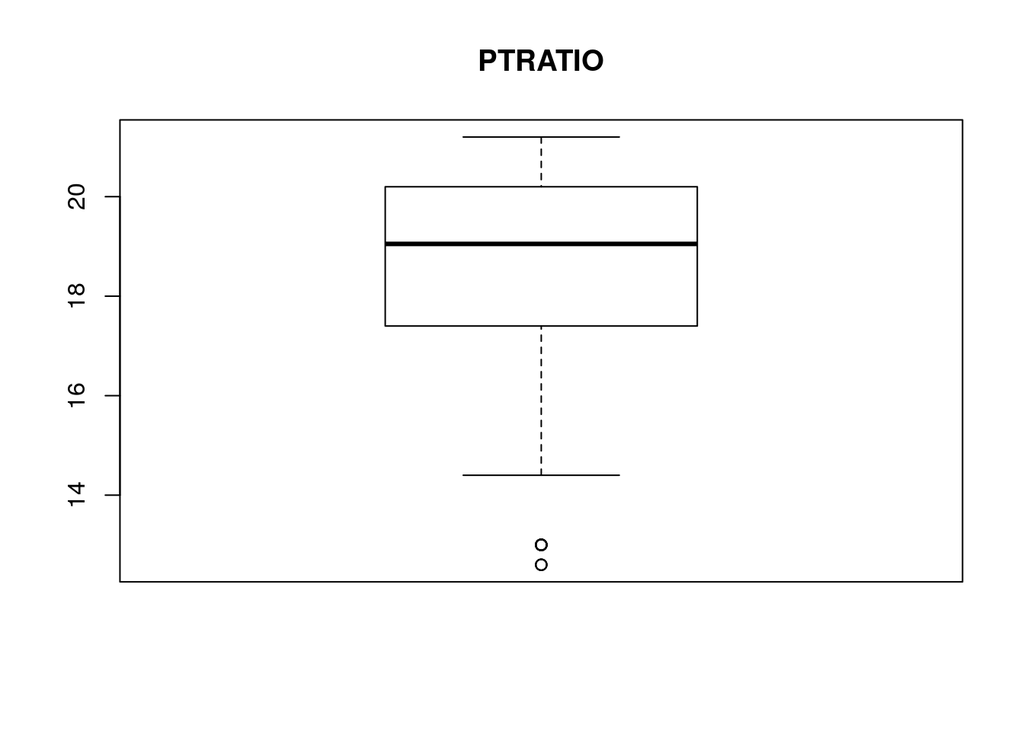

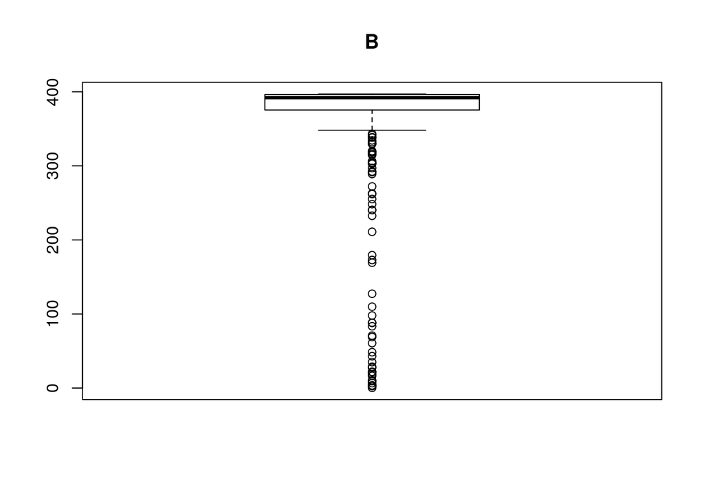

[1 more figures not shown]

```r
# Boxplots for each attribute
# par(mfrow=c(dispRow,dispCol))
for(i in 1:totAttr) {
    boxplot(x_train[,i], main=names(x_train)[i])
}
```

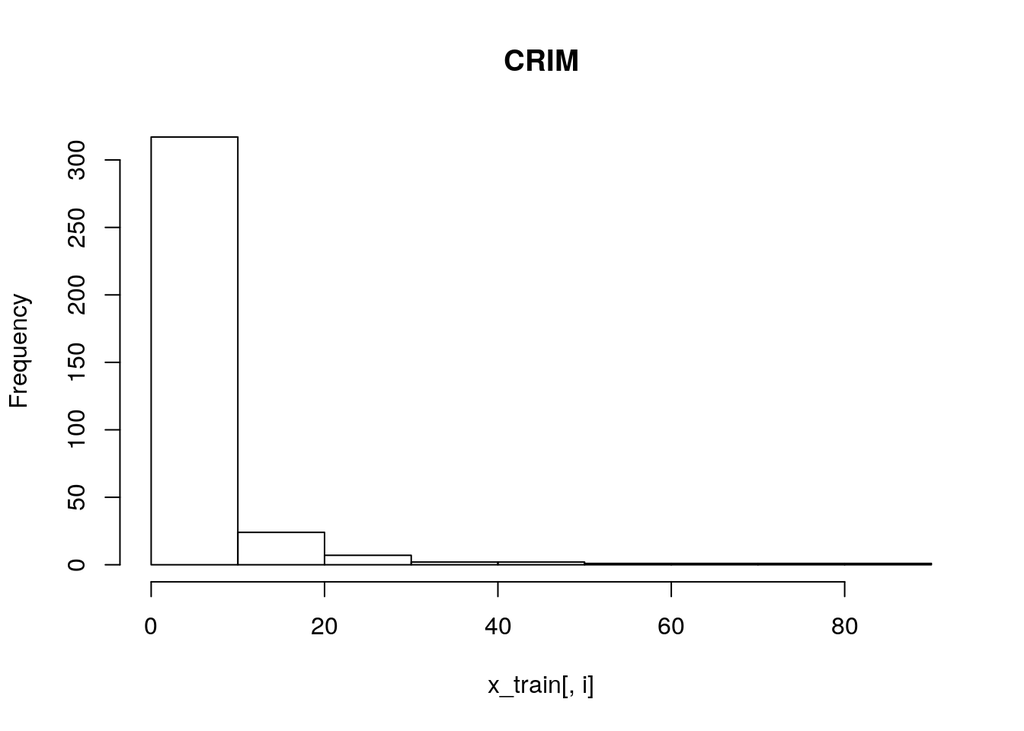

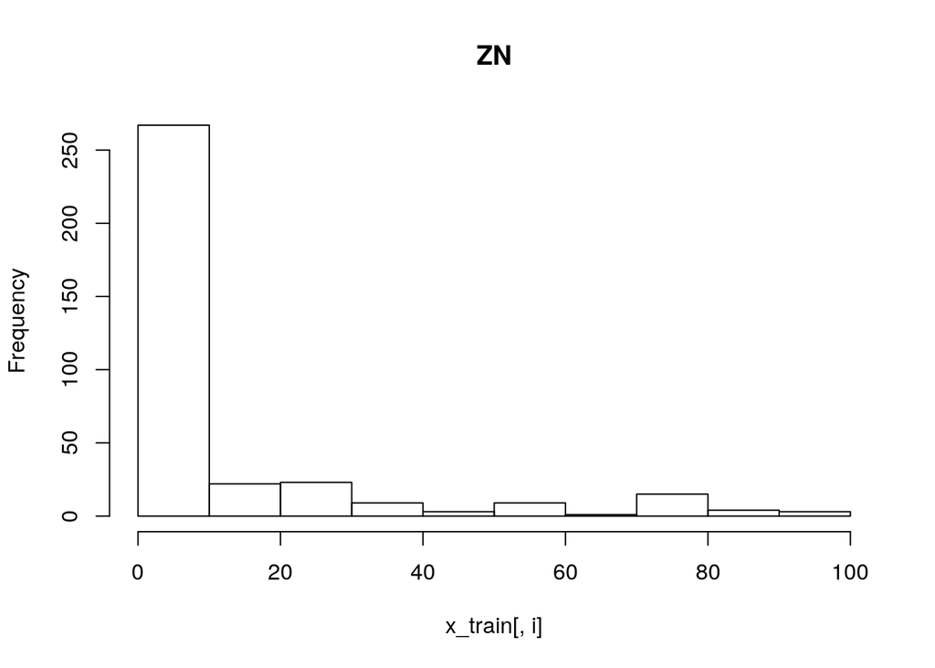

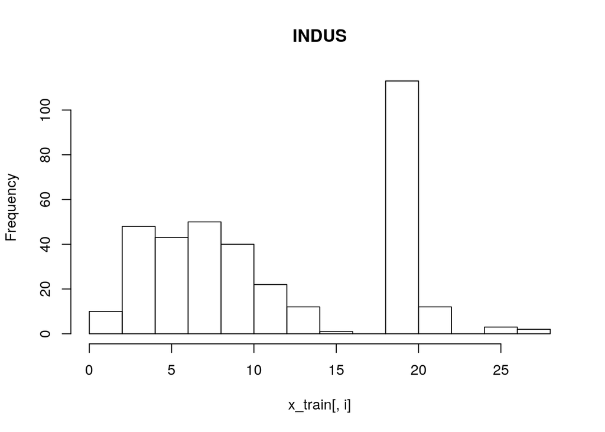

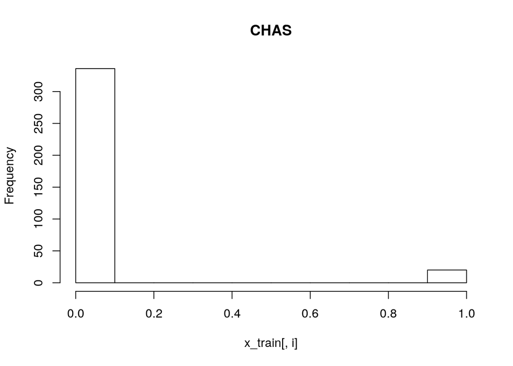

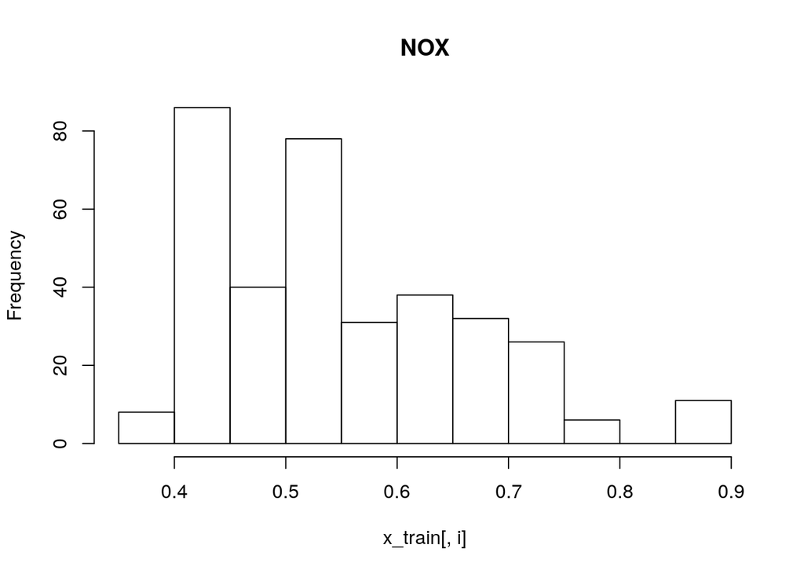

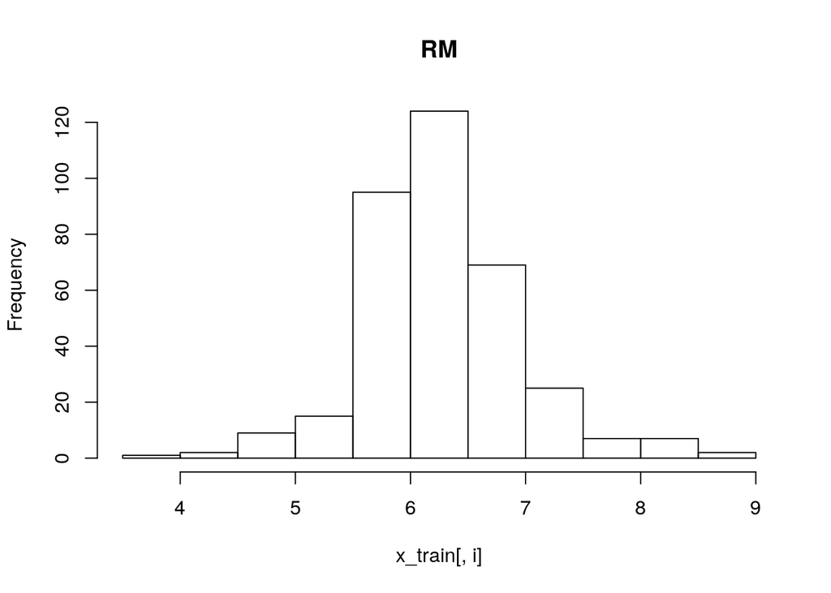

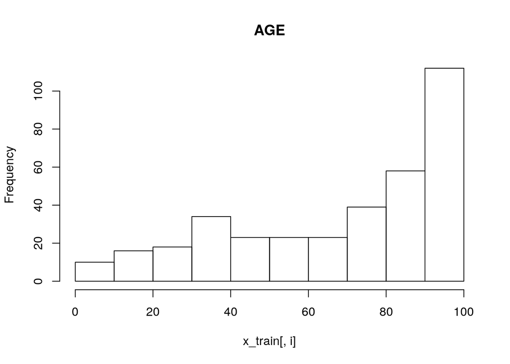

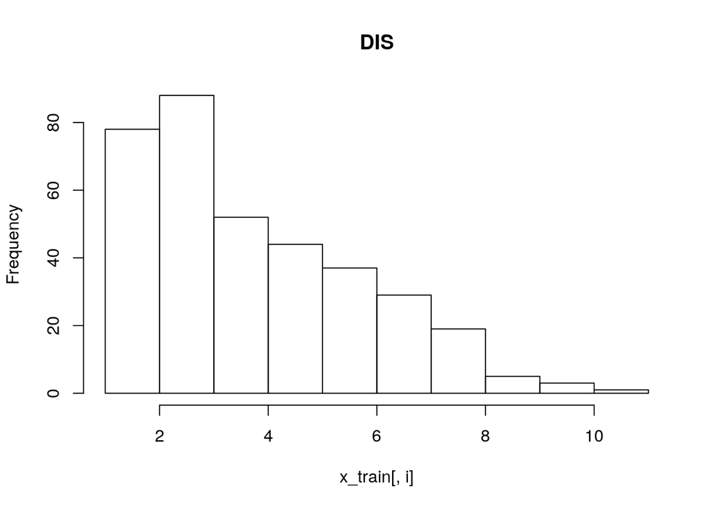

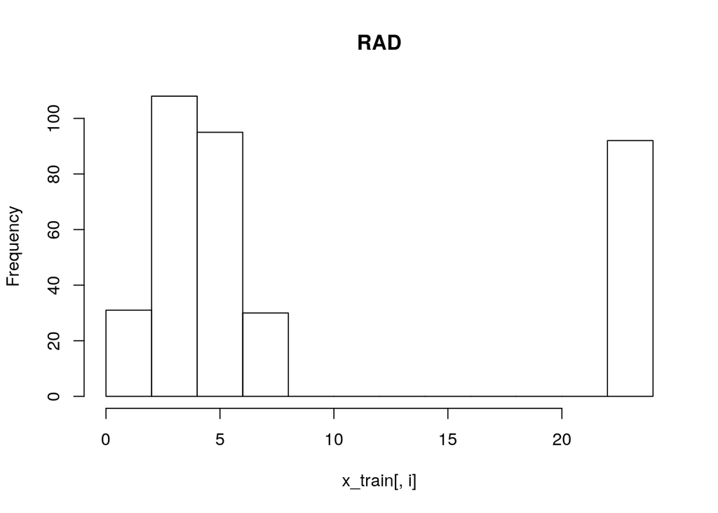

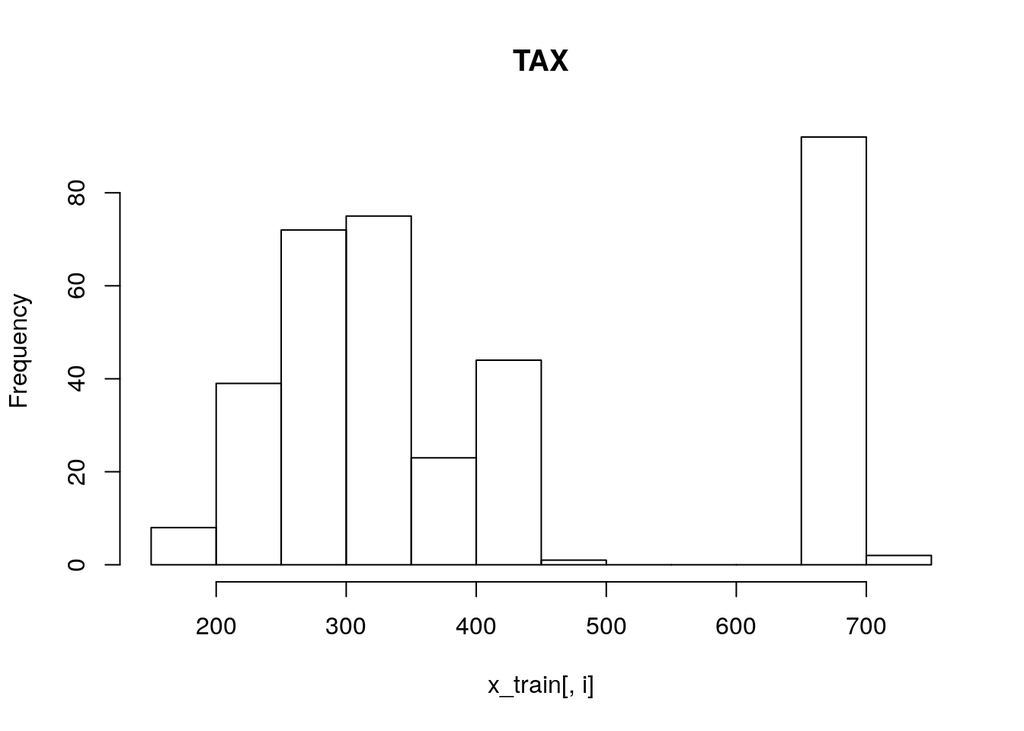

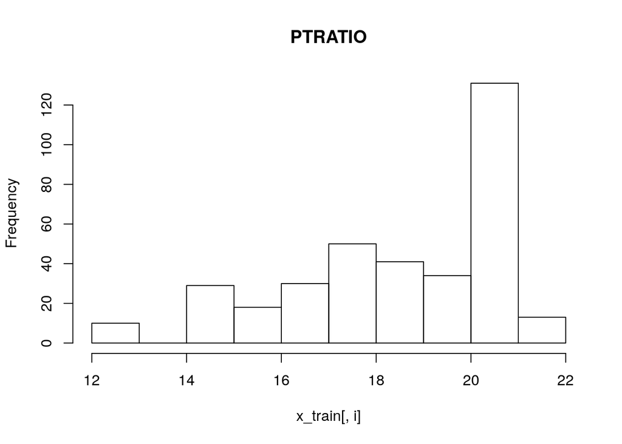

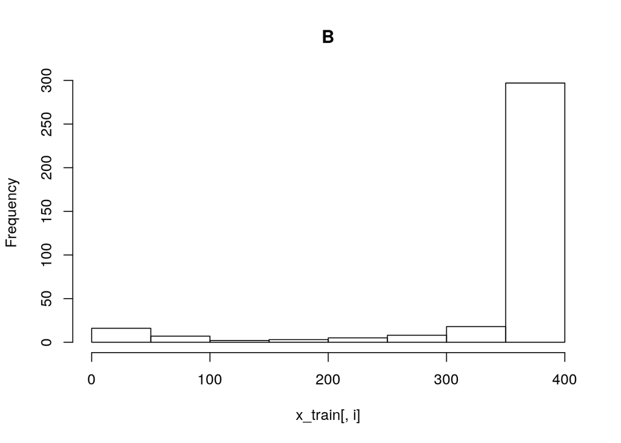

[1 more figures not shown]

```r
# Histograms each attribute
# par(mfrow=c(dispRow,dispCol))
for(i in 1:totAttr) {
    hist(x_train[,i], main=names(x_train)[i])
}
```